# Project 1 - Throwing Strikes

Austin, Hannah, Jake, Kyle

2024-10-01

[output not shown]

[output not shown]

[output not shown]

[output not shown]

[output not shown]

[output not shown]

```
## # A tibble: 6 × 7
##   PitchNo TaggedPitchType PitchCall Extension InducedVertBreak Balls Strikes
##     <dbl> <fct>               <dbl>     <dbl>            <dbl> <dbl>   <dbl>
## 1      11 Sinker                  1      6.25             7.56     0       0
## 2      12 Changeup                0      6.27             3.02     0       1
## 3      13 Sinker                  0      6.09             5.86     1       1
## 4      15 Changeup                0      6.25            -1.96     0       0
## 5      16 Sinker                  0      6.10             8.62     1       0
## 6      19 Four-Seam               0      6.21            13.7      0       0
```

## Research Topic and Dataset Selection

This project examines how pitch characteristics and count context relate to the probability of a pitch being called a ball or strike. Using pitch-level data from an individual pitcher, a logistic regression model was developed using pitch type, extension, balls, and strikes as predictors. The goal was to identify which characteristics were associated with pitch outcomes and evaluate how well logistic regression could classify pitch results.

- Pitch Type: Four-Seam, Sinker, Change-up, Slider
- Count: number of balls and number of strikes for the player at-bat
- Extension: Point of balls release from hand to the pitching rubber

## Data Preparation

The original dataset contained approximately 20 variables describing each pitch. The data was cleaned and reduced to variables relevant to the modeling objective, including pitch type, extension, balls, and strikes. Pitch-call outcomes that did not fit the binary classification objective, such as balls put into play and foul balls, were removed. The remaining observations were used to model the binary pitch-call outcome.

## Logistic Regression Statistical Analysis

```
##
## Call:
## glm(formula = PitchCall ~ TaggedPitchType + Extension + Balls +
##     Strikes, family = binomial(), data = pacheco)
##
## Coefficients:
##                         Estimate Std. Error z value Pr(>|z|)
## (Intercept)             29.05519   10.98574   2.645  0.00817 **
## TaggedPitchTypeSinker    0.04598    0.71487   0.064  0.94872
## TaggedPitchTypeChangeup  0.30862    1.09255   0.282  0.77758
## TaggedPitchTypeSlider   -1.26420    0.91483  -1.382  0.16700
## Extension               -4.88013    1.81064  -2.695  0.00703 **
## Balls                    0.28548    0.33499   0.852  0.39411
## Strikes                 -0.04107    0.43319  -0.095  0.92446
## ---
## Signif. codes:  0 '***' 0.001 '**' 0.01 '*' 0.05 '.' 0.1 ' ' 1
##
## (Dispersion parameter for binomial family taken to be 1)
##
##     Null deviance: 104.039  on 75  degrees of freedom
## Residual deviance:  91.662  on 69  degrees of freedom
## AIC: 105.66
##
## Number of Fisher Scoring iterations: 4
```

## Traditional Logistic Regression

```
##             (Intercept)   TaggedPitchTypeSinker TaggedPitchTypeChangeup
##             29.05518627              0.04597989              0.30861834
##   TaggedPitchTypeSlider               Extension                   Balls
##             -1.26420223             -4.88012587              0.28547579
##                 Strikes
##             -0.04107407
```

```
##                                  ORs        2.5 %       97.5 %
## (Intercept)             4.154388e+12 6.804170e+03 5.862614e+22
## TaggedPitchTypeSinker   1.047053e+00 2.549749e-01 4.344847e+00
## TaggedPitchTypeChangeup 1.361543e+00 1.354342e-01 1.136586e+01
## TaggedPitchTypeSlider   2.824645e-01 4.338399e-02 1.629495e+00
## Extension               7.596058e-03 1.598518e-04 2.112929e-01
## Balls                   1.330395e+00 6.932204e-01 2.610720e+00
## Strikes                 9.597580e-01 4.042727e-01 2.249380e+00
```

## Model Interpretation

- Four-Seam: Four-seam fastballs serve as the reference category for pitch type. The coefficients for the other pitch types therefore represent differences relative to the four-seam fastball.
- Sinker: The sinker coefficient was close to zero and was not statistically significant, providing little evidence of a difference from the four-seam baseline in this dataset.
- Changeup: The changeup also was not statistically significant. Its relatively wide confidence interval indicates substantial uncertainty in the estimated effect.
- Slider: The slider had a negative coefficient relative to the four-seam baseline, but the effect was not statistically significant at the 0.05 level.

## Traditional Logistic Regression

- Extension: Extension was statistically significant in the full logistic regression model (p ≈ 0.007). Its negative coefficient indicates that greater extension was associated with lower odds of the outcome coded as 1, holding the other predictors constant.
- Balls: The number of balls in the count was not statistically significant in this model (p ≈ 0.394).
- Strikes: The number of strikes was also not statistically significant (p ≈ 0.924).

Among the predictors included in the model, extension provided the strongest statistical evidence of an association with pitch outcome in this dataset.

## Logistic Regression with Machine Learning

The full-data logistic regression and train/test logistic regression served different purposes in this analysis. The full-data model was useful for examining coefficients, odds ratios, confidence intervals, and statistical significance, while the train/test approach provided a more appropriate evaluation of predictive performance on unseen observations. Because the full-data model was evaluated using observations involved in model fitting while the predictive model was evaluated on held-out observations, their accuracy and AUC values should not be interpreted as a direct head-to-head comparison.

## Logistic Regression with Machine Learning

```
##
## Call:
## glm(formula = PitchCall ~ TaggedPitchType + Extension + Balls +
##     Strikes, family = binomial(), data = PachecotrainData)
##
## Coefficients:
##                         Estimate Std. Error z value Pr(>|z|)
## (Intercept)             19.49525   11.15712   1.747   0.0806 .
## TaggedPitchTypeSinker   -0.26295    0.76813  -0.342   0.7321
## TaggedPitchTypeChangeup  0.05522    1.17347   0.047   0.9625
## TaggedPitchTypeSlider   -0.80162    1.00267  -0.799   0.4240
## Extension               -3.26157    1.82775  -1.784   0.0743 .
## Balls                    0.14543    0.38237   0.380   0.7037
## Strikes                  0.20260    0.49167   0.412   0.6803
## ---
## Signif. codes:  0 '***' 0.001 '**' 0.01 '*' 0.05 '.' 0.1 ' ' 1
##
## (Dispersion parameter for binomial family taken to be 1)
##
##     Null deviance: 74.563  on 53  degrees of freedom
## Residual deviance: 68.864  on 47  degrees of freedom
## AIC: 82.864
##
## Number of Fisher Scoring iterations: 4
```

## Logistic Regression with Machine Learning

```
## Confusion Matrix and Statistics
##
##           Reference
## Prediction  0  1
##          0 10  0
##          1  4  8
##
##                Accuracy : 0.8182
##                  95% CI : (0.5972, 0.9481)
##     No Information Rate : 0.6364
##     P-Value [Acc > NIR] : 0.05554
##
##                   Kappa : 0.6452
##
##  Mcnemar's Test P-Value : 0.13361
##
##             Sensitivity : 0.7143
##             Specificity : 1.0000
##          Pos Pred Value : 1.0000
##          Neg Pred Value : 0.6667
##              Prevalence : 0.6364
##          Detection Rate : 0.4545
##    Detection Prevalence : 0.4545
##       Balanced Accuracy : 0.8571
##
##        'Positive' Class : 0
##
```

## Logistic Regression with Machine Learning

```
## [1] "Sensitivity:  0.714285714285714"
```

```
## [1] "Specificity:  1"
```

```
## [1] "Accuracy:  0.818181818181818"
```

```
## Area under the curve: 0.9018
```

## Logistic Regression with Machine Learning

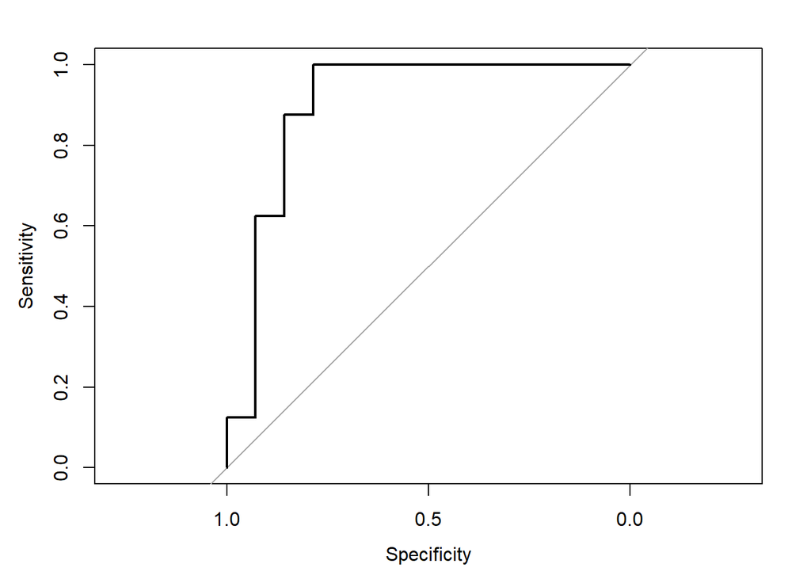

## Model Comparison

1. Prediction Comparison:
- Traditional Logistic Regression

```
## [1] "Sensitivity:  0.857142857142857"
```

```
## [1] "Specificity:  1"
```

```
## [1] "Accuracy:  0.909090909090909"
```

```
## Area under the curve: 0.9018
```

## Model Comparison

1. Prediction Comparison:
- Logistic Regression With Machine Learning

```
## [1] "Sensitivity:  0.714285714285714"
```

```
## [1] "Specificity:  1"
```

```
## [1] "Accuracy:  0.818181818181818"
```

```
## Area under the curve: 0.9018
```

## Model Comparison

2. Statistical Comparison:

```
## [1] "AIC LR:  105.661803308548"
```

```
## [1] "AIC LRML:  82.8643571544025"
```

- The training-set logistic regression produced a lower AIC than the full-data model. However, because the models were fit using different samples, these AIC values should not be treated as a direct model-selection comparison. AIC is most useful when comparing candidate models fit to the same response data.

This project demonstrated how logistic regression can be used to examine and predict binary pitch outcomes using pitch-level tracking data. Pitch type, extension, and count context were incorporated as predictors, with extension showing the strongest statistical evidence of an association with pitch outcome in the full-data model.

A train/test framework was also used to evaluate predictive performance on unseen observations. The held-out test results demonstrated that the model was capable of distinguishing between the two pitch-call outcomes, although the relatively small dataset limits how broadly the results should be generalized.

Overall, the project provided experience in baseball data preparation, feature selection, logistic regression, odds-ratio interpretation, binary classification, train/test validation, confusion matrices, and ROC/AUC evaluation. A natural next step would be to repeat the analysis with a larger pitch-level dataset and additional pitch characteristics to improve model validation and generalizability.